# Let's Bring In Some Help

## Preliminaries

In the last several modules we have begun to pick up skills in accessing data in a table and using maps and filtered-maps to build sub-tables and extract columns. Our eventual focus was on a starter table of Titanic passengers.

In this module, I'd like to show you how we can extend the Python language to get us to the next level. I want to bring in helpers that will (a) give us the ability to read spreadsheets off of the web, and (b) allow us to start analyzing our data by visualizing it.

## The `import` statement

We will be using a new python statement in this module called `import`. One of the reasons I like Python is it has a base programming language where you can do powerful things with a small set of concepts. Built-in to Python is also the ability bring in extensions to the language that do specific things. Do we require these extensions? Typically no; we could program the same thing in the base language. But the culture of Python is for the programming community to build collections of useful functions and then share them freely with everyone else. These collections are called *packages* in Python: they package up a new collection of functions that you can make use of in your code. One analogy is buying a new car. You typically are given a base model to start. Then you can buy packages to extend the base model. Python is the base model. You can "buy" Python packages with the `import` statement. The cool things are (a) the packages are free - no need to buy them, and (b) you install the package when you need it. It's kind of like quickly installing a V8 engine in your V6 model when needing to tow something. When not towing, just use the V6.

Let's try a simple example of importing using the `math` package (documentation at https://docs.python.org/2/library/math.html). I went to the web page that described all the cool functions the `math` package gives me and chose `sqrt` (square root function). To bring the `sqrt` function into my code, I use:

```
from math import sqrt
```

In words, *Hey, Python, I know there are lots of functions in the `math` package. I just want the `sqrt` function please*. BTW: this is a feature not typically found on cars. You have to get the full package - don't get to pick and choose what you want.

```python
from math import sqrt  # just import the sqrt function from math

x = 4
y = 13.8
print(sqrt(x))
print(sqrt(y))
```

```
2.0
3.7148351242
```

### Other ways you might see import used

Above we used a pick and choose strategy. We only wanted one function and asked for just that. Alternatively, we can bring the whole package in if we don't want to pick and choose. Here is the same code but now importing the entire `math` package.

```python
import math  # import the whole math package

x = 4
y = 13.8
print(math.sqrt(x))
print(math.sqrt(y))
```

```
2.0
3.7148351242
```

Notice that I could no longer just use `sqrt`. Now I need `math.sqrt`. That is the price you pay when bringing the whole package in. You have to prefix all the package's functions with the package name.

There is one more way we will see `import` used. It is a variation on above where we imported the entire package. The difference is that we can give the package a nick-name. Typically the nick-name is shorter than the whole name and hence easier to type. Let's give it a shot.

```python
import math as m  # whole math package but with nick-name m

x = 4
y = 13.8
print(m.sqrt(x))
print(m.sqrt(y))
```

```
2.0
3.7148351242
```

I still have to prefix the `sqrt` function but now get to use the nickname.

## There are a lot of Python packages

The `math` package is one of a large set of python packages. As you feel more comfortable in the base language, you can start to explore Python packages on the web. How can you find them? Well, I suppose you could browse them at https://pypi.python.org/pypi. But you will see that there are over 80K (yes, eighty thousand) packages listed. The way I find packages is to google for the problem I am trying to solve. For instance, a google search on "how to do square root in python" will turn up pointers to the `math` package and then the `sqrt` function. However, I do not want to sound too glib about this. Finding the right package is one thing. Trying to decipher how to use it is another. Some packages have great examples to help you understand what the author had in mind when she coded the functions in the package. Some packages have bare documentation. For the latter, I often find myself on a site like `stackoverflow.com` where discussions about a package's use are found in the form of question and answers.

Returning to my car analogy, maybe you have a really well-designed base car. Choose your favorite make. But packages for your base model were built by both good and bad automative engineers. Well engineered packages for your car are a joy to use; a seemless fit with your base car. Poorly designed or poorly documented packages are painful. You have to learn how they work by trial and error and even when you figure it out, they don't work very well in any case. How many of the 80,000 Python packages are well engineered? No one has tried to analyze that. My guess: less than 1%. I promise to only use the well-engineered ones in our course. That said, I am trying to stick to basic Python in this course. I will use packages sparingly. But now is the time to use a couple packages that really help us with our prediction goal.

## The CSV format

I'd like you to learn how to bring in spreadsheets on the web into your Python program. Up until now, we have been building tables from scratch. But that is not a sane way of dealing with large spreadsheets. What we would like is a way to read a spreadsheet off the web and build the equivalent Python version as a list of dictionaries.

There are a variety of applications you might use in your own work for handling spreadsheet data. Microsoft Excel is the big gorilla. But Google has Sheets, Apple has Numbers, etc. Miraculously, all the spreadsheet vendors have agreed on a common format to pass data between themselves. That format is called *comma-separated values* or CSV for short. It is not very exotic. It is a text file you can read with a standard text editor. The first line of the file always contains the column names. Each subsequent line in the file is a row of data.

The important point for us is that whatever spreadsheet program you are using with in your own work, you should have a save-as option to a CSV file. In this module we will see how to import a csv file into our Python code as a list of dictionaries. After the course is over, you can take your own spreadsheet data, save-as a CSV file then follow the steps in this module to import it to Python.

## Download a csv file from the web

The data I will use for examples in the remainder of the course is a spreadsheet of the Titanic disaster. The full Titanic spreadsheet is on the web as a CSV file. Let's see how to read it into Python.

You are probably accustomed to getting files off of the web by downloading them to your own computer. We are going to bypass that step and load a file directly off the web into our Python code. The cool thing is that we can read data from many of the popular cloud storage apps, e.g., Dropbox, Google docs. I have placed the titanic data on my Google docs (actually Google sheets).

```python
import pandas as pd # helps with handling csv formatted data

url = 'https://docs.google.com/spreadsheets/d/e/2PACX-1vRfRGwbQzwBPwjcvSw5j8ekURpBukF6Xh5K95Nk4tP3nrzpJUl38XQDzJEPXP4Qy3RZfn5-UW6up1Eg/pub?output=csv'

df = pd.read_csv(url)  # reads in the data from web

df_fill = df.fillna('') # replace empty values with empty string

df_dict = df_fill.T.to_dict() # create dictionary

titanic_table  = df_dict.values() # convert to final form

titanic_table[0]  # the first row of the table - Mr. Braund
```

```
{'Age': 22.0,
 'Cabin': '',
 'Embarked': 'S',
 'Fare': 7.25,
 'Name': 'Braund, Mr. Owen Harris',
 'Parch': 0,
 'PassengerId': 1,
 'Pclass': 3,
 'Sex': 'male',
 'SibSp': 1,
 'Survived': 0,
 'Ticket': 'A/5 21171'}
```

## What's up with all that new code?

You can see we are importing the `pandas` package to help us. And giving it the nickname `pd`. The `pandas` package is way useful for dealing with csv files off the web. That's one of its specialities. The `pandas` function `read_csv` sucks data from a url and builds a special `pandas` piece of data called a *dataframe*. I am not going to go into detail on what a dataframe looks like - it is complicated and we only will make use of it briefly to build our list of dictionaries. The remaining 3 lines use methods that work on dataframes: `fillna`, `T.to_dict()` and `values`. What we end up with is our table in the variable `titanic_table`.

## Assembly line concept

First let me say that you can treat the above code as a "chunk" that you can copy and paste. The only variation in the whole chunk is the `url` - use a new url string to read in a new spreadsheet. Optionally (but suggested), you can change the table name from `titanic_table` to `league_standings_table` or `loan_table` or whatever makes sense for your new data.

Let's take a little deeper look into what is happening in the above code. It's a bit like an assembly line. You build your base unit, the dataframe, and store it in `df`. Now you pass it along the line for methods to add pieces to it. Eventually you have the finished product in `titanic_table`. This is such a standard way of doing things in Python, it has been given a name: *workflow*. We will see the assembly line (workflow) idea crop up again when we turn to plotting in a few sections further.

While the assembly line form is simple to describe, figuring out how to use all these packaged functions and methods in concert (i.e., the workflow) is challenging. That's the downside of packages. You have to figure out what the programmer who built the package was thinking and how to use that in your own code. If you don't use the correct functions or get them out of order, you will end up with a strange and useless end-product.

## We have a table!

After we execute the csv code above, we have a table in the form we want: a list of dictionaries where each dictionary represents a passenger row in the original spreadsheet. You can see the first row in the table (`titanic_table[0]`) represents a passenger *Braund*.

Let's see how many rows the table has.

```python
len(titanic_table)
```

```
891
```

## How many survived?

I claim that what we have learned in past modules should apply to this larger table. Let's do a reality check. I'll see if I can count the total number of survivors by using a filtered map.

```python
survivor_table = [row for row in titanic_table if row["Survived"] == 1] #filtered map
survivor_count = len(survivor_table) #length of table equals the total survivors

print(survivor_count)
```

```
342
```

## An alternative using the count method

The `count` method will also be useful to us in later modules so let's take a first look at it for counting survivors. Here are some simple examples of using `count`.

```python
x = [1,2,3,4,2,1]
print(x.count(1))  # should find 2 occurences of 1 in the list
print(x.count(3))  # should find 1 occurence of 3 in the list
```

```
2
1
```

Also works for strings.

```python
y = ['yes', 'yes', 'no', 'yes']

print( y.count('yes'))  # 3 occurences
print( y.count('no'))  # 1 occurence
```

```
3
1
```

I'll use an alternative to the filtered-map above: I'll pull the entire Survived column out then count how many times 1 appears.

```python
survived_column = [row['Survived'] for row in titanic_table]
s_count = survived_column.count(1)
print( s_count )
```

```
342
```

What's the difference between the 2 strategies I've shown you? This code builds a sub-table:

```
survivor_table = [row for row in titanic_table if row["Survived"] == 1] #filtered map
```

This code pulls out the values in a column:

```
survived_column = [row['Survived'] for row in titanic_table]
```

Sometimes you want a sub-table, sometimes you want a column. We will practice doing both in following modules.

## A note about printing

[output not shown]

[output not shown]

Here is a trick to print just the first few items of a table or column:

```python
first_3_rows = titanic_table[:3]
first_5_items = survived_column[:5]
print(first_3_rows)  # first 3 rows
print(first_5_items)  # first 5 items
```

```
[{'Fare': 7.25, 'Name': 'Braund, Mr. Owen Harris', 'Embarked': 'S', 'Age': 22.0, 'Parch': 0, 'Pclass': 3, 'Sex': 'male', 'Survived': 0, 'SibSp': 1, 'PassengerId': 1, 'Ticket': 'A/5 21171', 'Cabin': ''}, {'Fare': 71.2833, 'Name': 'Cumings, Mrs. John Bradley (Florence Briggs Thayer)', 'Embarked': 'C',…
[0, 1, 1, 1, 0]
```

It is an extension of what you already know. You know you can get a specific item (e.g., the 0th item) out of the titanic_table using `titanic_table[0]`. You can get the first 3 items using `titanic_table[:3]`. Handy to know. We will eventally get to a spreadsheet that has over 25,000 rows - don't want to be printing all of those out.

### One other trick

You can print out values without the print statement! Sometimes. Here is an example.

```python
titanic_table[:3]  # notice no print statement
```

```
[{'Age': 22.0,
  'Cabin': '',
  'Embarked': 'S',
  'Fare': 7.25,
  'Name': 'Braund, Mr. Owen Harris',
  'Parch': 0,
  'PassengerId': 1,
  'Pclass': 3,
  'Sex': 'male',
  'SibSp': 1,
  'Survived': 0,
  'Ticket': 'A/5 21171'},
 {'Age': 38.0,
  'Cabin': 'C85',
  'Embarked': 'C',
  'Fare': 71.2833,
  'Name': 'Cumings, Mrs. John Bradley (Florence Briggs Thayer)',
  'Parch': 0,
  'PassengerId': 2,
  'Pclass': 1,
  'Sex': 'female',
  'SibSp': 1,
  'Survived': 1,
  'Ticket': 'PC 17599'},
 {'Age': 26.0,
  'Cabin': '',
  'Embarked': 'S',
  'Fare': 7.925,
  'Name': 'Heikkinen, Miss. Laina',
  'Parch': 0,
  'PassengerId': 3,
  'Pclass': 3,
  'Sex': 'female',
  'SibSp': 0,
  'Survived': 1,
  'Ticket': 'STON/O2. 3101282'}]
```

I like this better than the print version. It formats it a little more cleanly.

## Real data has empty values

I've been shielding you from empty values in the starter tables we have been working with. But real tables will have missing values in some of the cells. These values may be missing for different reasons, e.g., someone forgot to fill them in, they are unknown. We will learn how to replace them with real values in the next module. For now, we will just skip over them.

## Skipping over empty values

If I want to pull out a column of values, but skip over the empty values, I can employ my guard from module 3. The guard will filter out empty values. But the guard needs to know what an empty value looks like. It is not zero - that could be a legitimate value. What everyone has agreed on for an empty value is the empty string. An empty string is an opening quote and closing quote with nothing in between. Here are a couple examples:

```python
empty_string1 = ''  # using single quotes
empty_string2 = ""  # using double quotes
```

Ok, I think we have enough to work on a column with empties. Let's choose Age - I can tell you the Age column has missing values (empties). Here is the code to pull out the Age column and skip over empty values. First I'll pull out the whole column then a column filtering out empties.

```python
raw_age_column = [passenger['Age'] for passenger in titanic_table]  # this will have empty values

filtered_age_column = [passenger['Age'] for passenger in titanic_table if passenger['Age'] != '']  # no empty values

print(len(raw_age_column))
print(len(filtered_age_column))
```

```
891
714
```

Looks like we are missing 177 Age values. Wow. We will have to come back to this in module 5.

## Let's plot that data

We imported the `pandas` package to help us read data off the web. Let's look at another package to help us plot that data. The package is called `matplotlib.pyplot`. Why the period in the name? In fact, there is just a plain `matplotlib` package. But it is so big, they broke it into sub-packages. One of those sub-packages is `pyplot`. That's the one we will use. Here is the code to import what we want.

```python
%matplotlib inline

import matplotlib.pyplot as plt  # use plt as the nick-name
```

### Magic command

The line `%matplotlib inline` is *not* Python. It's a command to the notebook. It really is called a magic command - I did not make that up. It tells the notebook to show the plots as part of the notebook output. Pretty nice.

The actual `import` statement should be recognizable - bring in the entire `pyplot` sub-package and give it the nick-name `plt`.

### Histogram will be our main plotting tool

We have lots of plotting styles to choose from in `pyplot`. For this course, we will focus on a histogram, which is basically a bar chart.

[figure not shown]

Here are some of the shapes we might see in a histogram.

[figure not shown]

### Let's check how age plots out

Was there a normal distribution of ages for passengers on the Titanic? Or were there more older (or more younger) passengers? We can use a histogram to find out. We will follow these steps:

1. Build a list by extracting the `Age` column from the table. Skip over (filter out) empty values.
2. Create a histogram for the list using 10 bars. This function comes from `plt`.
3. Actually show the plot in the notebook. This function comes from `plt`.

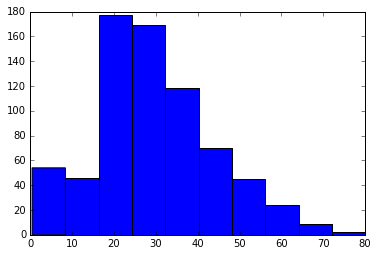

```python
nonempty_ages = [row['Age'] for row in titanic_table if row['Age'] != '']  # step 1

plt.hist(nonempty_ages, 10)  # step 2

plt.show()  # step 3
```

### What can we notice?

Ages range from 0 to 80. It is somewhat right-skewed (a longer tail on the right). The younger ages are less in number than you might expect. Or maybe you would expect it - not that many kids on an ocean voyage. Just eyeballing it, I'd guess the average age is around 30.

Also useful to know the width of a bar. The oldest passenger was 80. And we have 10 bars. If we divide 80 by 10, we get the bar width of 8. So the first bar on the left represents ages 0-7, the next bar ages 8-15, etc.

### Let's try fares

Let's see if we can reuse the steps for age, with some modifications, to get fares:

1. Build a list by extracting the `Fare` column from the table. Skip over empty values.
2. Create a histogram for the list using 10 bars. This function comes from `plt`.
3. Actually show the plot in the notebook. This function comes from `plt`.

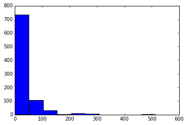

```python
nonempty_fares = [row['Fare'] for row in titanic_table if row['Fare'] != '']  # step 1

plt.hist(nonempty_fares, 10)  # step 2

plt.show()  # step 3
```

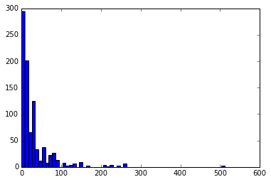

```python
plt.hist(nonempty_fares, 60)  # step 3

plt.show()  # step 4
```

That is kind of interesting. Many between 0-20 (first 2 bars). Then a drop off at 20-30. Then a spike at 30-40. Then a big drop-off that remains.

## Put the plots on the assembly line

We build our base component with `plt.hist` but then don't do anything more with it other than show it. Let's do some value added to the plot before showing it. What I would like is to add a label on x-axis, a label on y-axis, and a title. We will do that as part of the assembly line that goes between constructing the plot (step 3) and showing the plot (step 4).

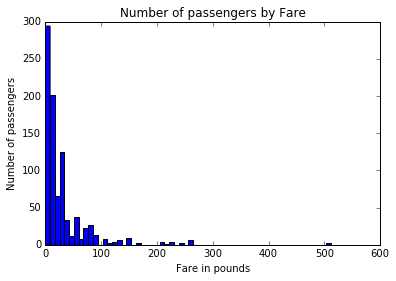

```python
plt.hist(nonempty_fares, 60)  # step 3

plt.xlabel("Fare in pounds")  # one step on assembly line

plt.ylabel("Number of passengers")  # one step on assembly line

plt.title("Number of passengers by Fare")  # one step on assembly line

plt.show()  # step 4
```

That's better. Can now show it to the boss.

## Next up

We have to deal with those empties!